# Is war in our genes?

Thomas Chadefaux

PO 4700: Contemporary International Relations

## Today’s lecture

> - War in human nature?
> - The end of war?
> - The long peace

# 1. War in Human Nature?

## The 1971 Tanzanian war

[interactive chart not shown]

#### Notes

- Peaceful inter-community relations until 1971.
- Late 1970: President Leakey dies.
- Coup from general Humphrey
- Challenged by Hugh and Charlie in the South
- Immediately, two factions emerge: North and South
- Communities that were interconnected fall apart, inter-community exchanges decrease
- The war lasts four years. Humphrey decimates the south and ultimately wins.
- Men were systematically beaten, killed, disembowelled or castrated
- Women were often beaten or raped
- Babies often stolen or killed
- … but this was not an actual war!

## The 1971 Tanzanian war The Gombe war

- Chimpanzee conflict
- recorded by Jane Goodall

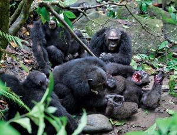

Chimpanzees fighting

## Is war or conflict a human specificity?

- Standard view until 1960s: intraspecies killings are specific to humans
- But much evidence to the contrary
  - Chimpanzees
  - Lions
- At the same time, other species can also cooperate
  - Trees
  - Sea rocket
  - Ground squirrels

#### Notes

We used to think so up to the 1960s. Yet there is large evidence that animals are no more peaceful than we are.

- In particular, we used to think that intra-species killing were rare, but they are in fact one of the main causes of mortality.
  - Chimpanzees are highly territorial:
    - Males patrol the boundaries of the group’s territory and attack intruders
    - Raid foreign territories.
  - Infants very vulnerable
    - New leader of a lion pride kills the cubs of the previous leader.
    - Siblings often kill/canibalize each other, esp. when food is short.
  - Intraspecific killing among humans $\leq$ other animal species.
    - According to some, it is many times inferior to that of any mammalian species studied
  - Overall, humans are not an exception in killing their kind.
- Yet, not all species are equally violent
  - Common chimpanzee is violent
  - Pigmy chimpanzee or bonobos less so
- Are humans closer to the Bonobos?

## Is war or conflict a human specificity?

[video not shown]

## Is war or conflict a human specificity?

[figure not shown]

#### Notes

- Douglas fir and paper birch trees transfer carbon, nitrogen and phosphorus between them via mycelia
- Large trees help out small, younger ones

For me: http://www.bbc.com/earth/story/20141111-plants-have-a-hidden-internet

See also Suzanne Simard’s Ted talk (optional):

[interactive chart not shown]

## Humans in the state of nature

- Hobbes
- Rousseau

How do we know?

#### Notes

- The two philosophers travel and meet aboriginal peoples.
- Hobbes:
  - Endemic ``war’‘, murderous feuds for gain, safety, and reputation, a war of every man against every man, which made life ‘poore, nasty, brutish, and short’ (Leviathan, 1651, 13).
  - The creation of the state—the leviathan—was the only system that could guarantee at least internal peace.
- Rousseau’s Discourse on the Origins and Foundation of Inequality among Mankind (1755):
  - aboriginal humans lived harmoniously in nature, with abundant resources
  - But with the coming of
    - agriculture
    - demographic growth
    - private property
    - $\Rightarrow$ war
- So who was right? And how do we know?

## Humans in the state of nature: Three sources of information

- Study of animal aggression and fighting
- Hunter-gatherers
  - surviving ones
  - prehistoric evidence
- Evolutionary theory

## Did hunter-gatherers fight?

- The problem of evidence
- Contamination problems
- Today’s hunter-gatherers are different: isolated, poor environments
- Evidence from the Pleistocene is inconclusive
- Best: Australian Lab

#### Notes

- Problem: Hunter–gatherers have no written records, so the evidence comes from those in contact with them. Recent and historical hunter–gatherers interacted with agriculturalists and pastoralists, often fighting over products and livestock $\Rightarrow$ violence. These are contaminated samples.
- How do we observe `pure’ examples of hunter–gatherers?
- Evidence from archeological records, esp. bones: at least some of them were injured in combat (note: we know it’s in combat by examining the damage to the bone. Damage to a living bone is different from damage incurred after death).

## Did hunter-gatherers fight?

- The myth of the peaceful savage
- 1960s: peaceful aborigines, e.g. Arctic Eskimos But:
  - harsh environment -> thinly spread
  - Diffuse resources, hard to monopolise
  - High level of violence
  - 90% of hunter-gatherer societies have intergroup warfare at least every 2 years

#### Notes

- The surviving hunter-gatherer groups have survived perhaps for a reason. I.e., they are not representative of the prehistorical hunter-gatherers.
  - Largely confined to poor environments (Arctic, deserts) unsuitable for agriculture
  - Low population densities
  - Move a lot to subsist
  - Few possessions
- Poster case was the central Canadian Arctic Eskimos
  - Not surprising given harsh environment and thinly spread. Resources very diffuse and hard to monopolize
  - Even then, they had a very high rate of quarrels, blood feuds, and homicide (often to kidnap women). 10 times higher than USA at their peak of 1990
  - Other Eskimos living in different conditions (e.g., Greenland and coastal Alaska) were strongly territorial and war-like.
- Another poster case: the Kalahari Bushmen, east African Hadza, and central African Pygmies, celebrated as peaceful.
  - Yet clear evidence that there was fighting not only with their agricultural neighbors, but also among themselves even before contact with non-hunter–gatherers.
  - Homicide rates very high, far higher than US or any other state society
  - Much of that fighting centered on the water-holes vital for survival in this area,
  - Only with enforcement of law by Canada and southern Africa did violence rates decrease.
- A comparative study of 99 hunter-gatherer groups, belonging to 37 different cultures, found that nearly all engaged in warfare. Most engaged in intergroup warfare at least every two years (on par with other human societies)

# 2. The decline of war(?)

## Three major steps in the decline of violence

- Rise of the state-leviathan
- 1815–1945
- 1945–

## Hobbes was right

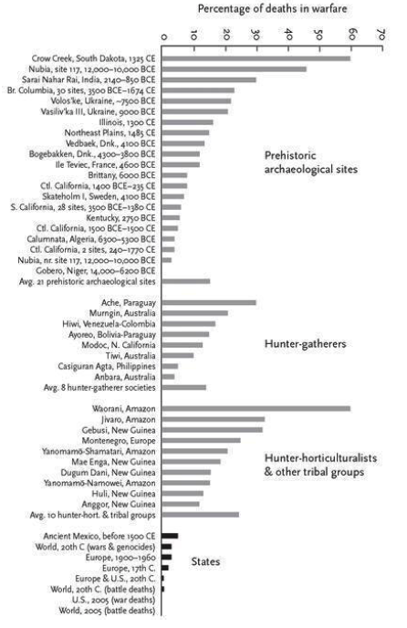

Percentage of deaths in warfare in nonstate and state societies (Pinker, p. 49)

## But the 20th century was the bloodiest, right?

- Yes, in terms of absolute casualties.
- But not in terms of % of population killed

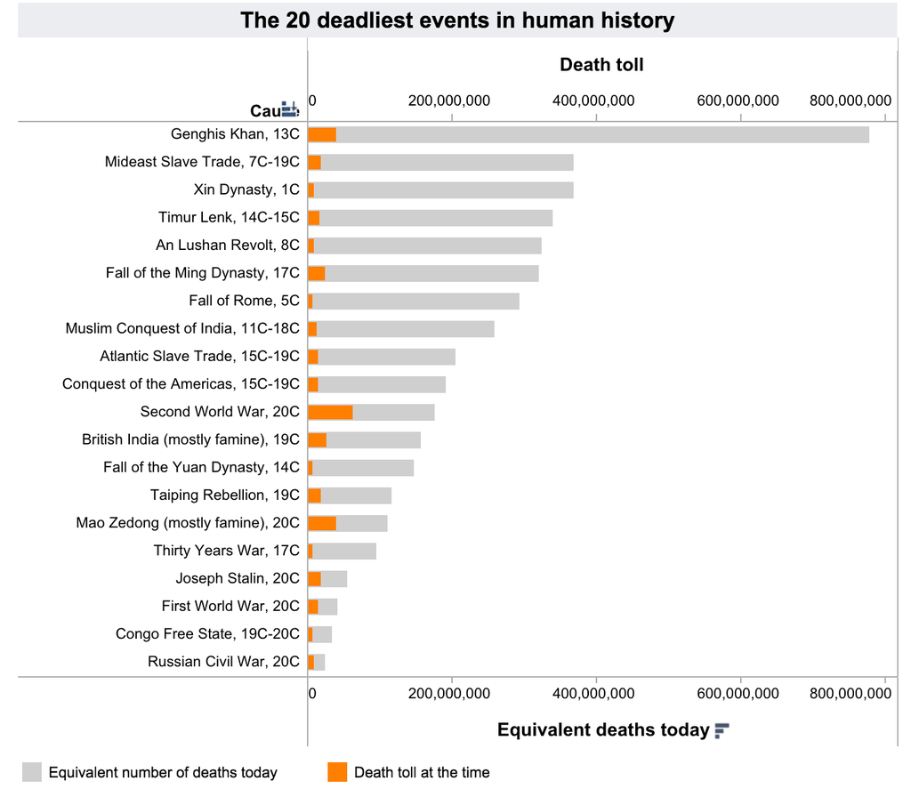

## But the 20th century was the bloodiest, right?

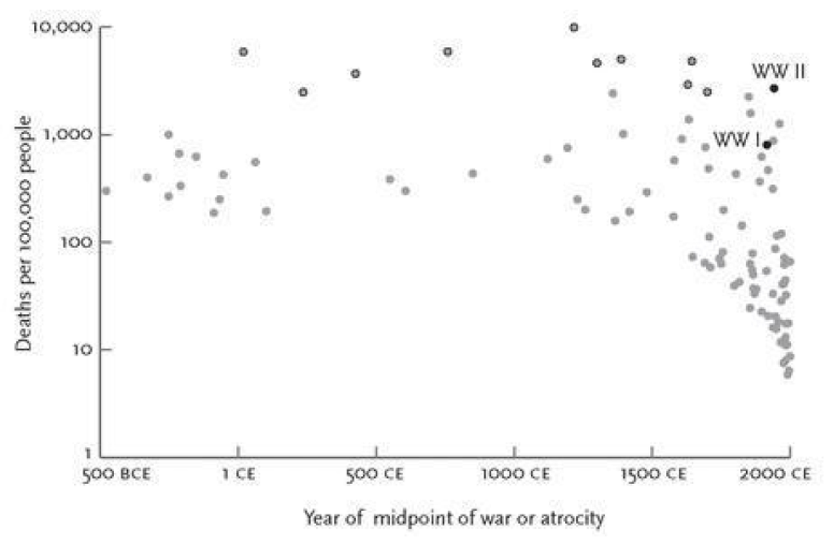

Source: Pinker p. 197

## But is war-deaths per capita the right metric?

- Maybe fewer people exposed to risk of death (i.e., not less war-prone)
- Death may decrease because medicine improves
- Population growth is exponential
- Leaders never know ex ante how many deaths

#### Notes

For more info on this and the next few slides:

- Braumoeller: Is War Disappearing
- See also: http://www.popsci.com/technology/article/2013-08/have-we-seen-end-war-wait-200-years-find-out

## Better measure of war-proneness: of Arsonists and Trees

Deaths per capita may be the wrong measure of war-proneness

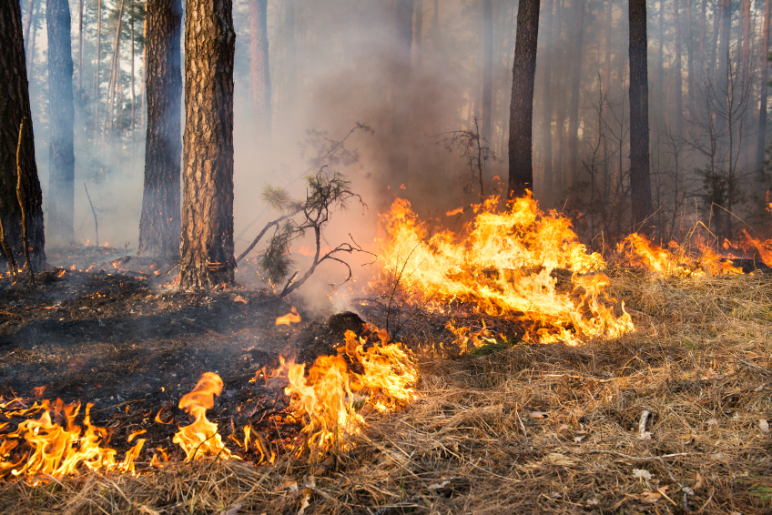

## So, has the NUMBER of wars decreased?

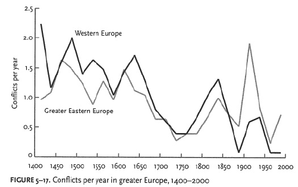

#### Notes

But why limit our attention to Europe?

## So, has the NUMBER of wars decreased?

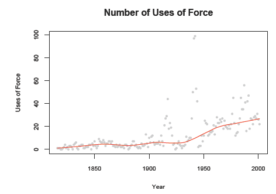

#### Notes

Are we satisfied with that?

Problem: no correction is made for the number of interaction opportunities in the international system. Ther are far more states now than 100 years ago.

## So, has the NUMBER of wars decreased?

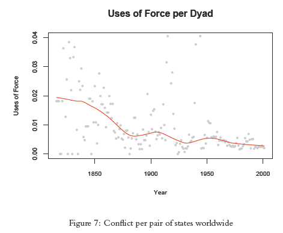

#### Notes

To correct for this issue, divide the number of uses of force in a given year by the number of pairs of states (` dyads’) present in the international system.

Are we satisfied with that? No. Most states cannot project power beyond thier own region. A clash between Bolivia and Botswana is unlikely, because they are too weak and do not care about each other

We need to include political relevance.

## So, has the NUMBER of wars decreased?

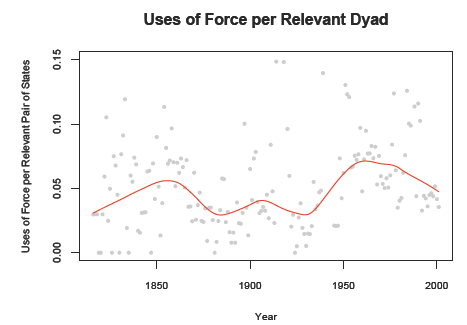

# 3. The long peace (1945–)

## What is the long peace?

- 0 nuclear weapons used
- 0 tactical nuclear weapons used
- 0 war between great powers
- 0 interstate wars in Europe
- 0 interstate wars between major developed countries
- 0 forced territory expansion by developed countries (exception: Israel)
- 0 states have disappeared through conquest

#### Notes

The proponents of the end of war argument counter by saying that the period since the end of World War II has been remarkably peaceful.

## Why the long peace?

- Territorial integrity norm
- Democratization
- Decline of role of state to preserve honor
- Commerce
- The bomb?

## Is the long peace really surprising?

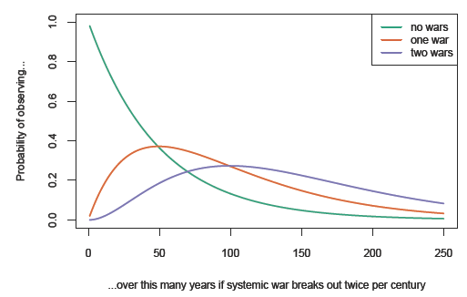

#### Notes

Related discussion (optional):

[interactive chart not shown]